# bcRep: Advanced Analysis of B Cell Receptor Repertoire Data

## Principal coordinate analysis on distance matrices

Principal coordinate analysis can be performed on distance matrices. The function dist.PCoA() provides principal coordinate objects, like in ‘ape::pcoa()’, with an output as follows (taken from ape::pcoa):

- correction: value of parameter and correction variable, if any
- note: type of correction
- values : The eigenvalues and related information:
  - Eigenvalues: all eigenvalues (positive, null, negative)
  - Relative_eig: relative eigenvalues
  - Corr_eig: corrected eigenvalues
  - Rel_corr_eig: relative eigenvalues after Lingoes or Cailliez correction.
  - Broken_stick: expected fractions of variance under the broken stick model.
  - Cumul_eig: cumulative relative eigenvalues.
  - Cum_corr_eig: cumulative corrected relative eigenvalues.
  - Cumul_br_stick: cumulative broken stick fractions.
- vectors: the principal coordinates with positive eigenvalues.
- trace: the trace of the distance matrix. This is also the sum of all eigenvalues, positive and negative.
- vectors.cor: the principal coordinates with positive eigenvalues from the distance matrix corrected using the method specified by parameter correction.
- trace.cor: the trace of the corrected distance matrix. This is also the sum of its eigenvalues.

The results can also be plotted, using ‘plotDistPCoA()’. Input has to be the PCoA table from ‘dist.PCoA()’, a ‘groups’ data.frame and a pair of axes to be plotted. Optional arguments are names, plotCorrection (default: FALSE), title, plotLegend (default: FALSE) and PDF.

```r
# Example for gene usage data:
data(vgenes)
vgenes<-vgenes[,1:10] # include only genes 1-10
gu.dist<-geneUsage.distance(geneUsage.tab = vgenes, method = "bc")
gu.pcoa<-dist.PCoA(dist.tab = gu.dist, correction = "cailliez")
```

```r
str(gu.pcoa) # a PCoA object
```

```
## List of 1
##  $ :List of 7
##   ..$ correction : chr [1:2] "cailliez" "3"
##   ..$ note       : chr "Cailliez correction applied to negative eigenvalues: D' = -0.5*(D + 0.0607817555282937 )^2, except diagonal elements"
##   ..$ values     :'data.frame':  10 obs. of  6 variables:
##   .. ..$ Eigenvalues : num [1:10] 0.1688 0.0608 0.026 0.0196 0.0126 ...
##   .. ..$ Corr_eig    : num [1:10] 0.2148 0.0877 0.0417 0.0349 0.0253 ...
##   .. ..$ Rel_corr_eig: num [1:10] 0.4908 0.2003 0.0953 0.0798 0.0578 ...
##   .. ..$ Broken_stick: num [1:10] 0.3397 0.2147 0.1522 0.1106 0.0793 ...
##   .. ..$ Cum_corr_eig: num [1:10] 0.491 0.691 0.786 0.866 0.924 ...
##   .. ..$ Cum_br_stick: num [1:10] 0.34 0.554 0.707 0.817 0.897 ...
##   ..$ vectors    : num [1:10, 1:7] -0.1721 -0.1274 0.0216 0.2608 0.1213 ...
##   .. ..- attr(*, "dimnames")=List of 2
##   .. .. ..$ : chr [1:10] "Sample1" "Sample2" "Sample3" "Sample4" ...
##   .. .. ..$ : chr [1:7] "Axis.1" "Axis.2" "Axis.3" "Axis.4" ...
##   ..$ trace      : num 0.29
##   ..$ vectors.cor: num [1:10, 1:8] -0.1945 -0.1477 0.0271 0.2896 0.1399 ...
##   ..$ trace.cor  : num 0.438
##   ..- attr(*, "class")= chr "pcoa"
```

```r
# Example of a 'groups' data.frame: in the case, there are two groups:
groups.vec<-cbind(rownames(vgenes),c(rep("group1",5),rep("group2",5)))
colnames(groups.vec)<-c("Sample","Group")
pandoc.table(groups.vec)
```

| Sample | Group |
| --- | --- |
| Sample1 | group1 |
| Sample2 | group1 |
| Sample3 | group1 |
| Sample4 | group1 |
| Sample5 | group1 |
| Sample6 | group2 |
| Sample7 | group2 |
| Sample8 | group2 |
| Sample9 | group2 |
| Sample10 | group2 |

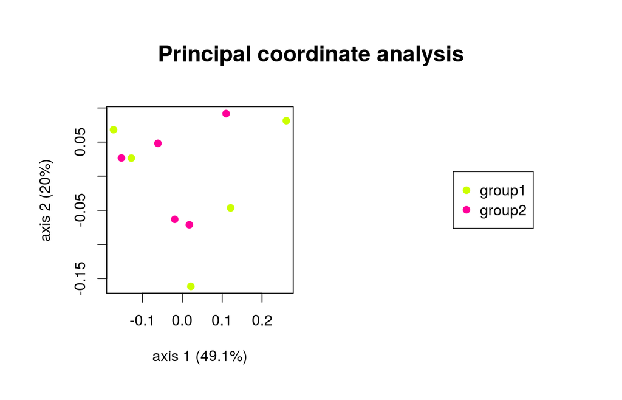

```r
plotDistPCoA(pcoa.tab = gu.pcoa, groups= groups.vec, axes = c(1,2),
             names = rownames(vgenes), plotLegend = TRUE)
```

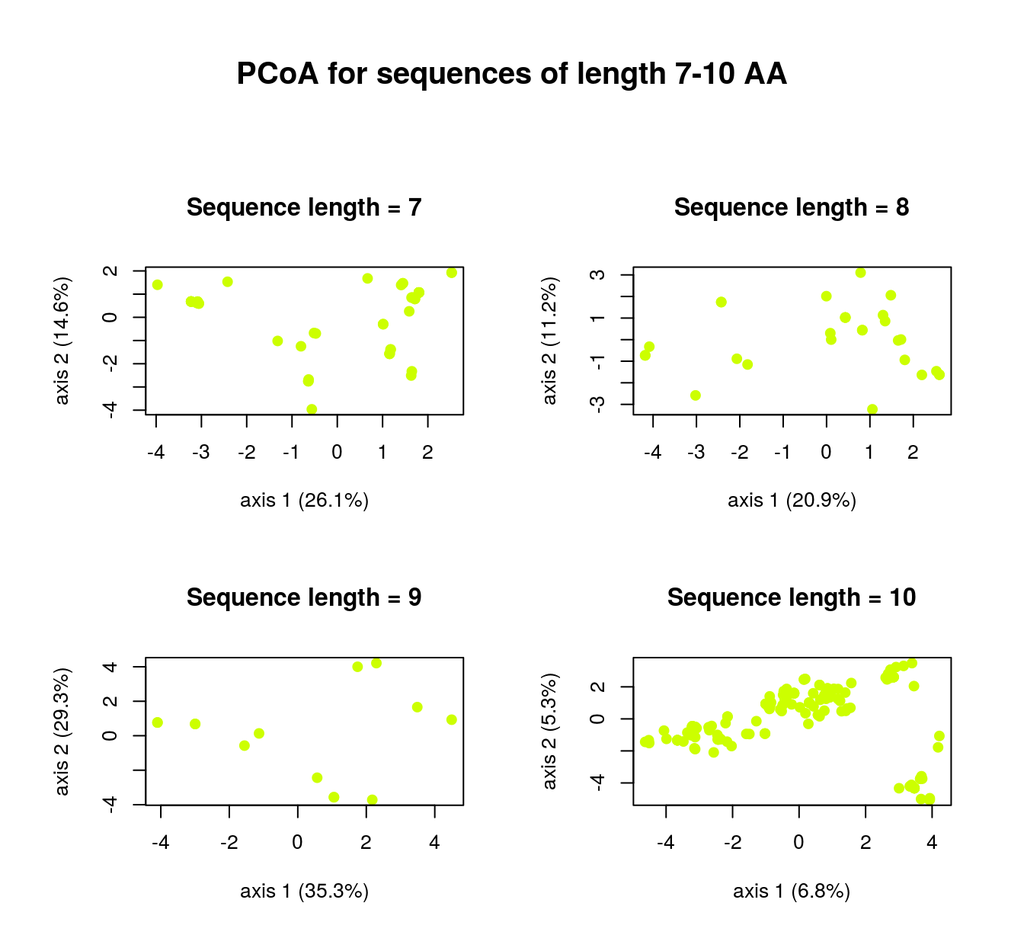

```r
# Example for sequence data, divided into subsets of the same length:
data(clones.ind)
clones.ind<-subset(clones.ind, CDR3_length_AA %in% c(7:10)) # include only CDR3 sequences of 7-10 AA
seq.dist<-sequences.distance(sequences = clones.ind$unique_CDR3_sequences_AA,
     method = "levenshtein", divLength=T)
seq.pcoa<-dist.PCoA(dist.tab = seq.dist, correction = "none")

# Example of a 'groups' data.frame:
## in the case, there are no groups (all samples have the same group):
groups.vec<-unlist(apply(data.frame(clones.ind$unique_CDR3_sequences_AA),1,
                         function(x){strsplit(x,split=", ")[[1]]}))
groups.vec<-cbind(groups.vec, 1)

plotDistPCoA(pcoa.tab = seq.pcoa, groups=groups.vec, axes = c(1,2),
             plotCorrection = FALSE,
             title = 'PCoA for sequences of length 7-10 AA', plotLegend=FALSE)
```